# Handling Large Blobs + FTP + Python Chunking / Offset / Multipart Download

This notebook summarizes:

- Handling large blobs in system design
- Presigned URLs
- Multipart / resumable uploads
- Metadata synchronization
- CDN downloads
- Common interview deep dives
- FTP failed-download handling
- Python techniques for chunking, offset resume, multipart download, checksum, retries, and production handling

# Index

1. Problem with Large Files
2. Why Blob Storage
3. Correct Architecture
4. Presigned URLs
5. Direct Upload Flow
6. Direct Download Flow
7. Blob Storage URL vs CDN Signed URL
8. Resumable / Multipart Uploads
9. Progress Tracking
10. Metadata Management
11. State Synchronization Problem
12. Correct Synchronization
13. Abuse Prevention
14. Fast Downloads
15. Cloud Provider Terminology
16. When to Use
17. When NOT to Use
18. Deep Dive: Upload Fails at 99%
19. Deep Dive: Prevent Abuse
20. Deep Dive: Handle Metadata
21. Deep Dive: Ensure Fast Downloads
22. FTP Big File Download Failure
23. FTP Resume Using Offset
24. Python Technique: Basic Chunk Download
25. Python Technique: HTTP Resume Using Offset
26. Python Technique: Production Retry Logic
27. Python Technique: Multipart / Parallel Download
28. Python Technique: FTP Resume Download
29. Python Technique: Checksum Verification
30. Best Practice Summary
31. Golden Interview Answer

# 1. Problem with Large Files

Large files like videos, images, PDFs, documents, and backups should not be routed through application servers.

Bad design:

```
Client
  ↓ uploads 2GB video
API Server
  ↓ forwards file
Blob Storage
```

Problems:

- API server becomes a bottleneck
- High bandwidth cost
- Slow uploads and downloads
- Server timeout risk
- Poor scalability
- Application servers act like dumb pipes

The application server adds little value when it only forwards bytes.

⬆ Back to Index

# 2. Why Blob Storage

Use blob/object storage for large files.

Examples:

- Videos
- Images
- PDFs
- Documents
- Audio files
- Backups
- Large exports

Blob storage gives:

- Massive scalability
- High durability
- Cheaper storage
- Independent scaling from database
- Better support for large binary objects

Rule:

```
If file > 10 MB and does not need SQL queries
→ Store in blob storage
```

Examples:

- AWS S3
- Google Cloud Storage
- Azure Blob Storage

⬆ Back to Index

# 3. Correct Architecture

Correct approach:

```
Client
  ↓ request upload permission
API Server
  ↓ returns presigned URL
Client
  ↓ uploads file directly
Blob Storage
```

The API server handles:

- Authentication
- Authorization
- Quota checks
- Metadata creation
- Presigned URL generation

The API server does not handle actual file bytes.

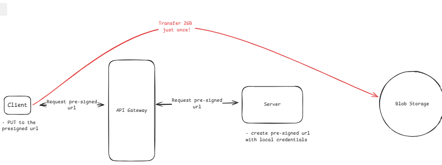

⬆ Back to Index

# 4. Presigned URLs

A presigned URL is a temporary URL that allows a client to upload or download a specific file.

It usually contains:

- File path / object key
- HTTP method
- Expiry time
- Signature
- Optional restrictions

Restrictions can include:

- Maximum file size
- Minimum file size
- Content type
- Upload path
- Expiry time

Example:

```
Upload allowed only for:
- One file path
- Limited time
- Specific size
- Specific content type
```

Typical expiry:

```
15 minutes to 1 hour
```

Benefits:

- Secure temporary access
- No cloud credentials exposed
- Server avoids file transfer
- Client uploads directly to storage

⬆ Back to Index

# 5. Direct Upload Flow

Direct upload flow:

```
1. Client requests upload
2. API validates user
3. API creates DB record with status = pending
4. API generates presigned upload URL
5. Client uploads directly to blob storage
6. Storage event confirms upload
7. Worker updates DB status = completed
```

The database stores metadata and upload status.

Blob storage stores the actual file bytes.

⬆ Back to Index

# 6. Direct Download Flow

Private download flow:

```
Client
  ↓ asks for download
API Server
  ↓ generates signed URL
Client
  ↓ downloads directly
Blob Storage / CDN
```

For frequently accessed files, use CDN:

```
Client
  ↓
CDN
  ↓ cache miss
Blob Storage
```

Examples:

- CloudFront
- Cloud CDN
- Azure CDN

⬆ Back to Index

# 7. Blob Storage URL vs CDN Signed URL

| Type | Validated By | Use Case |
| --- | --- | --- |
| Blob storage presigned URL | S3 / GCS / Azure Blob | Direct upload/download |
| CDN signed URL | CDN edge server | Fast global download |

Use CDN when:

- File is downloaded frequently
- Users are global
- Low latency matters
- Media delivery matters
- Cache helps reduce origin load

⬆ Back to Index

# 8. Resumable / Multipart Uploads

Problem:

```
5 GB upload fails at 99%
```

Without resumable upload:

```
Start again from 0%
```

Correct solution:

```
Chunked / Multipart Upload
```

Example:

```
File split into 100 parts

Part 1 uploaded
Part 2 uploaded
...
Part 60 uploaded
Connection fails
Resume from Part 61
```

Cloud equivalents:

| Cloud | Feature |
| --- | --- |
| AWS S3 | Multipart Upload |
| GCS | Resumable Upload |
| Azure Blob | Block Blob Upload |

After all parts upload, the client calls a completion endpoint so storage can assemble the final object.

⬆ Back to Index

# 9. Progress Tracking

With chunked upload:

```
Completed parts / Total parts
```

Example:

```
60 / 100 parts uploaded = 60%
```

This enables:

- Progress bar
- Resume support
- Retry only failed chunks
- Better UX for large uploads

⬆ Back to Index

# 10. Metadata Management

Store file metadata in the database.

Example:

```
files (
    id,
    user_id,
    filename,
    size_bytes,
    content_type,
    storage_key,
    status,
    created_at,
    updated_at
)
```

Blob storage stores:

```
Actual file bytes
```

Database stores:

```
Metadata and status
```

Common statuses:

```
pending
uploading
completed
failed
```

Do not rely on object tags for rich queries. Use the database for metadata.

⬆ Back to Index

# 11. State Synchronization Problem

Because upload bypasses API server:

```
Database and blob storage can become inconsistent
```

Common problems:

| Problem | Example |
| --- | --- |
| Client lies | Marks upload completed without uploading |
| Client crashes | File uploaded but DB not updated |
| Race condition | DB says completed before file exists |
| Orphan file | File exists but no DB record |
| Network failure | Completion callback never reaches API |

⬆ Back to Index

# 12. Correct Synchronization

Use storage events.

```
Blob Storage
  ↓ upload completed event
Queue / Event System
  ↓
Worker
  ↓
Update DB status = completed
```

Examples:

| Cloud | Event System |
| --- | --- |
| AWS S3 | S3 Event Notifications |
| GCS | Pub/Sub |
| Azure Blob | Event Grid |

Also run reconciliation jobs:

```
Find DB rows stuck in pending
Check storage
Fix status
```

Best design:

- Events are primary mechanism
- Reconciliation catches missed events

⬆ Back to Index

# 13. Abuse Prevention

Do not immediately expose uploaded files.

Use quarantine flow:

```
Upload
  ↓
Quarantine Bucket
  ↓
Virus Scan / Validation
  ↓
Approved Bucket
  ↓
Available to users
```

Validate:

- File size
- File type
- Content type
- Virus / malware
- Inappropriate content
- User quota

Also include file-size limits in presigned URL conditions.

⬆ Back to Index

# 14. Fast Downloads

Use:

```
CDN + Signed URLs + Range Requests
```

Range requests allow partial download:

```
Range: bytes=0-10485759
```

Benefits:

- Resume failed downloads
- Better large-file performance
- Browser/download manager support
- CDN caching near users

For very large files, parallel chunk downloads can help, but CDN + range requests is usually enough.

⬆ Back to Index

# 15. Cloud Provider Terminology

| Feature | AWS | GCP | Azure |
| --- | --- | --- | --- |
| Temporary upload URL | Presigned URL | Signed URL | SAS Token |
| Multipart upload | Multipart Upload | Resumable Upload | Block Blob |
| Event notifications | S3 Events | Pub/Sub | Event Grid |
| CDN signed URLs | CloudFront | Cloud CDN | Azure CDN |
| Cleanup | Lifecycle Rules | Lifecycle Management | Lifecycle Policies |

⬆ Back to Index

# 16. When to Use

Use this pattern for:

```
Files > 10 MB
```

Examples:

| System | Use Case |
| --- | --- |
| YouTube | Video uploads |
| Instagram | Photo uploads |
| Dropbox | File sync |
| WhatsApp | Media sharing |
| Google Drive | Large file sharing |
| Data platforms | Large exports/imports |

⬆ Back to Index

# 17. When NOT to Use

Do not use this pattern for:

| Case | Why |
| --- | --- |
| Small files | API upload is simpler |
| JSON/form data | Not blob data |
| Real-time validation required | Server must inspect bytes |
| Compliance scanning before storage | Server/proxy may be needed |
| Instant content-based response | Async processing may be too slow |

For small files, direct API upload is often simpler and good enough.

⬆ Back to Index

# 18. Deep Dive: Upload Fails at 99%

Use chunked / multipart upload.

```
Upload parts independently
Retry only failed parts
Complete upload after all parts succeed
```

Also store upload session ID so the client can resume later.

Examples:

- S3 upload ID
- GCS resumable upload URL
- Azure block upload session

Cleanup incomplete uploads using lifecycle rules after:

```
24–48 hours
```

⬆ Back to Index

# 19. Deep Dive: Prevent Abuse

Use:

- Presigned URL expiry
- Max file size condition
- Content type validation
- User quota
- Quarantine bucket
- Virus scan
- Content moderation
- Move to public bucket only after validation

Important:

```
Do not immediately expose uploaded files.
```

⬆ Back to Index

# 20. Deep Dive: Handle Metadata

Keep metadata in DB.

Good storage key pattern:

```
uploads/{user_id}/{timestamp}/{uuid}
```

Do not let users choose storage keys because it can cause:

- Overwrites
- Path guessing
- Security issues

Storage key connects object storage event back to DB row.

⬆ Back to Index

# 21. Deep Dive: Ensure Fast Downloads

Use:

```
CDN
Signed URLs
Cache headers
Range requests
```

For very large files:

```
Parallel chunk downloads
```

But usually:

```
CDN + Range Requests
```

is enough.

⬆ Back to Index

# 22. FTP Big File Download Failure

Problem:

```
FTP big file download fails in middle
```

Do not restart from zero.

Use resumable download.

Flow:

```
Download starts
   ↓
Network fails at 60%
   ↓
Check local partial file size
   ↓
Resume from byte offset 60%
   ↓
Download remaining part only
   ↓
Verify checksum / file size
```

Use a temporary partial file:

```
big_file.csv.part
```

After complete and verified:

```
big_file.csv.part → big_file.csv
```

⬆ Back to Index

# 23. FTP Resume Using Offset

FTP supports resume using the REST command.

```
REST <offset>
RETR <filename>
```

Example:

```
Local file size = 600 MB
Remote file size = 1 GB

Resume from byte 600 MB
```

In Python `ftplib`, this is done using:

```
rest=offset
```

⬆ Back to Index

# 24. Python Technique: Basic Chunk Download

Use this when the file is large but you do not need resume.

Key idea:

- Stream response
- Read chunk by chunk
- Do not load full file into memory

⬆ Back to Index

```python
import requests

url = "https://example.com/bigfile.zip"
output_file = "bigfile.zip"

chunk_size = 1024 * 1024  # 1 MB

with requests.get(url, stream=True, timeout=60) as response:
    response.raise_for_status()

    with open(output_file, "wb") as f:
        for chunk in response.iter_content(chunk_size=chunk_size):
            if chunk:
                f.write(chunk)

print("Download completed")
```

# 25. Python Technique: HTTP Resume Using Offset

Use HTTP `Range` header.

Example:

```
Range: bytes=5000000-
```

Meaning:

```
Start download from byte 5,000,000
```

Use `.part` file and append remaining bytes.

⬆ Back to Index

```python
import os
import requests

def download_with_resume(url, output_file, chunk_size=1024 * 1024):
    temp_file = output_file + ".part"

    downloaded_bytes = 0
    if os.path.exists(temp_file):
        downloaded_bytes = os.path.getsize(temp_file)

    headers = {}

    if downloaded_bytes > 0:
        headers["Range"] = f"bytes={downloaded_bytes}-"

    with requests.get(url, headers=headers, stream=True, timeout=60) as response:
        response.raise_for_status()

        mode = "ab" if downloaded_bytes > 0 else "wb"

        with open(temp_file, mode) as f:
            for chunk in response.iter_content(chunk_size=chunk_size):
                if chunk:
                    f.write(chunk)

    os.rename(temp_file, output_file)
    print("Download completed:", output_file)


# Example:
# download_with_resume(
#     url="https://example.com/bigfile.zip",
#     output_file="bigfile.zip"
# )
```

# 26. Python Technique: Production Retry Logic

Production version should include:

- Retry with backoff
- `.part` file
- Resume using offset
- HTTP status validation
- Final rename only after success

Valid status codes:

- `200` = full download
- `206` = partial content / resumed download

⬆ Back to Index

```python
import os
import time
import requests

def download_file_resumable(
    url,
    output_file,
    chunk_size=1024 * 1024,
    max_retries=5
):
    temp_file = output_file + ".part"

    for attempt in range(1, max_retries + 1):
        try:
            downloaded_bytes = 0

            if os.path.exists(temp_file):
                downloaded_bytes = os.path.getsize(temp_file)

            headers = {}

            if downloaded_bytes > 0:
                headers["Range"] = f"bytes={downloaded_bytes}-"

            with requests.get(
                url,
                headers=headers,
                stream=True,
                timeout=60
            ) as response:

                if response.status_code not in (200, 206):
                    raise Exception(f"Unexpected status code: {response.status_code}")

                mode = "ab" if downloaded_bytes > 0 else "wb"

                with open(temp_file, mode) as f:
                    for chunk in response.iter_content(chunk_size=chunk_size):
                        if chunk:
                            f.write(chunk)

            os.rename(temp_file, output_file)
            print("Download completed:", output_file)
            return

        except Exception as e:
            print(f"Attempt {attempt} failed:", e)

            if attempt == max_retries:
                raise

            sleep_time = attempt * 5
            time.sleep(sleep_time)


# Example:
# download_file_resumable(
#     url="https://example.com/bigfile.zip",
#     output_file="bigfile.zip"
# )
```

# 27. Python Technique: Multipart / Parallel Download

Use when:

- File is very large
- Server supports HTTP range requests
- You want faster downloads

Idea:

```
File size = 100 MB

Thread 1 → bytes 0-24 MB
Thread 2 → bytes 25-49 MB
Thread 3 → bytes 50-74 MB
Thread 4 → bytes 75-99 MB
```

Then merge part files into final file.

⬆ Back to Index

```python
import os
import math
import requests
from concurrent.futures import ThreadPoolExecutor, as_completed

def get_file_size(url):
    response = requests.head(url, allow_redirects=True, timeout=30)
    response.raise_for_status()

    if "Content-Length" not in response.headers:
        raise ValueError("Server did not return Content-Length")

    return int(response.headers["Content-Length"])


def download_part(url, start, end, part_file, chunk_size=1024 * 1024):
    headers = {
        "Range": f"bytes={start}-{end}"
    }

    with requests.get(url, headers=headers, stream=True, timeout=60) as response:
        if response.status_code != 206:
            raise Exception(
                f"Server did not return partial content. Status: {response.status_code}"
            )

        with open(part_file, "wb") as f:
            for chunk in response.iter_content(chunk_size=chunk_size):
                if chunk:
                    f.write(chunk)


def multipart_download(url, output_file, part_size=10 * 1024 * 1024, workers=4):
    file_size = get_file_size(url)
    total_parts = math.ceil(file_size / part_size)

    part_files = []

    with ThreadPoolExecutor(max_workers=workers) as executor:
        futures = []

        for part_number in range(total_parts):
            start = part_number * part_size
            end = min(start + part_size - 1, file_size - 1)

            part_file = f"{output_file}.part{part_number}"
            part_files.append(part_file)

            futures.append(
                executor.submit(download_part, url, start, end, part_file)
            )

        for future in as_completed(futures):
            future.result()

    with open(output_file, "wb") as final_file:
        for part_file in part_files:
            with open(part_file, "rb") as pf:
                final_file.write(pf.read())

            os.remove(part_file)

    print("Multipart download completed:", output_file)


# Example:
# multipart_download(
#     url="https://example.com/bigfile.zip",
#     output_file="bigfile.zip",
#     part_size=10 * 1024 * 1024,
#     workers=4
# )
```

# 28. Python Technique: FTP Resume Download

FTP uses the `REST` command internally.

In Python `ftplib`, use:

```
rest=offset
```

Flow:

1. Check local `.part` file size
2. Connect to FTP
3. Set binary mode
4. Resume using `rest=offset`
5. Rename after completion

⬆ Back to Index

```python
import os
from ftplib import FTP

def ftp_download_resume(
    host,
    username,
    password,
    remote_file,
    local_file,
    chunk_size=1024 * 1024
):
    temp_file = local_file + ".part"

    ftp = FTP(host)
    ftp.login(username, password)

    # Binary mode is important for non-text files and exact byte offsets
    ftp.voidcmd("TYPE I")

    offset = 0

    if os.path.exists(temp_file):
        offset = os.path.getsize(temp_file)

    with open(temp_file, "ab") as f:
        ftp.retrbinary(
            f"RETR {remote_file}",
            f.write,
            blocksize=chunk_size,
            rest=offset
        )

    ftp.quit()

    os.rename(temp_file, local_file)

    print("FTP download completed:", local_file)


# Example:
# ftp_download_resume(
#     host="ftp.example.com",
#     username="user",
#     password="password",
#     remote_file="/files/bigfile.csv",
#     local_file="bigfile.csv"
# )
```

# 29. Python Technique: Checksum Verification

After download, verify:

```
local file size == remote file size
```

Better:

```
local checksum == expected checksum
```

Use:

- MD5
- SHA256
- CRC32

If checksum fails:

- Delete partial/final file
- Retry download
- Or retry from last good chunk if chunk checksums are available

⬆ Back to Index

```python
import hashlib

def sha256_checksum(file_path):
    sha256 = hashlib.sha256()

    with open(file_path, "rb") as f:
        for chunk in iter(lambda: f.read(1024 * 1024), b""):
            sha256.update(chunk)

    return sha256.hexdigest()


# Example:
# print(sha256_checksum("bigfile.zip"))
```

# 30. Best Practice Summary

| Technique | Use Case |
| --- | --- |
| `iter_content()` | Stream large HTTP file |
| `.part` file | Avoid corrupt final file |
| HTTP `Range` header | Resume HTTP download |
| FTP `REST` / `rest=offset` | Resume FTP download |
| Parallel range download | Faster large file download |
| Checksum | Detect corruption |
| Retry with backoff | Handle network failures |
| DLQ / failed status | Production job handling |
| CDN | Fast global download |
| Range requests | Resume failed downloads |
| Multipart upload | Resume large uploads |

Production flow:

```
Start download
   ↓
Write to .part file
   ↓
Failure?
   ↓
Resume from offset
   ↓
Verify checksum / size
   ↓
Rename .part to final
   ↓
Mark job completed
```

⬆ Back to Index

# 31. Golden Interview Answer

For large files, I avoid routing bytes through application servers. The API authenticates the user, creates metadata, generates a presigned URL, and the client uploads directly to blob storage. For large uploads, I use multipart or resumable uploads. Storage events update the database after upload completion, and reconciliation jobs fix missed events. Downloads are served through CDN using signed URLs and range requests.

For FTP or HTTP large downloads, I stream data in chunks and write to a temporary `.part` file. If the download fails, I resume from the last downloaded byte using HTTP Range headers or FTP REST offset. For very large files, I can split the file into byte ranges and download parts in parallel, then merge them. After completion, I verify file size or checksum and rename the `.part` file to the final file.

⬆ Back to Index